# INDIA AIR QUALITY DATA ANALYSIS, VISUALISATION AND PREDICTION

###### Project by:

###### Place:

###### Submit to:

## Aim

To do data analysis on India Air Quality data and predict tha value of Air Quality Index based on given features of concentration of sulphur dioxide,nitrogen dioxide, respirable suspended particualte matter, suspended particulate matter and classify the Air Quality as good, moderate, poor, unhealthy, healthy.

The data is combined(across the years and states) and largely clean version of the Historical Daily Ambient Air Quality Data released by the Ministry of Environment and Forests and Central Pollution Control Board of India under the National Data Sharing and Accessibility Policy (NDSAP) year 1990-2015

#### The columns are

stn_code (station code)

sampling_date (date of sample collection)

state (Indian State)

location (location of sample collection)

agency

type (type of area)

so2 (sulphur dioxide concentration)

no2 (nitrogen dioxide concentration)

rspm (respirable suspended particualte matter concentration)

spm (suspended particulate matter)

location_monitoring_station

pm2_5 (particulate matter 2.5)

date

```python
import numpy as np
import pandas as pd
import seaborn as sns
import matplotlib.pyplot as plt
%matplotlib inline
```

```python
data = pd.read_csv('/content/data.csv',encoding = "ISO-8859-1") #import data
```

```python
data.head(10) #print first 10 rows
```

|  | stn_code | sampling_date | state | location | agency | type | so2 | no2 | rspm | spm | location_monitoring_station | pm2_5 | date |
| --- | --- | --- | --- | --- | --- | --- | --- | --- | --- | --- | --- | --- | --- |
| 0 | 150 | February - M021990 | Andhra Pradesh | Hyderabad | NaN | Residential, Rural and other Areas | 4.8 | 17.4 | NaN | NaN | NaN | NaN | 1990-02-01 |
| 1 | 151 | February - M021990 | Andhra Pradesh | Hyderabad | NaN | Industrial Area | 3.1 | 7.0 | NaN | NaN | NaN | NaN | 1990-02-01 |
| 2 | 152 | February - M021990 | Andhra Pradesh | Hyderabad | NaN | Residential, Rural and other Areas | 6.2 | 28.5 | NaN | NaN | NaN | NaN | 1990-02-01 |
| 3 | 150 | March - M031990 | Andhra Pradesh | Hyderabad | NaN | Residential, Rural and other Areas | 6.3 | 14.7 | NaN | NaN | NaN | NaN | 1990-03-01 |
| 4 | 151 | March - M031990 | Andhra Pradesh | Hyderabad | NaN | Industrial Area | 4.7 | 7.5 | NaN | NaN | NaN | NaN | 1990-03-01 |
| 5 | 152 | March - M031990 | Andhra Pradesh | Hyderabad | NaN | Residential, Rural and other Areas | 6.4 | 25.7 | NaN | NaN | NaN | NaN | 1990-03-01 |
| 6 | 150 | April - M041990 | Andhra Pradesh | Hyderabad | NaN | Residential, Rural and other Areas | 5.4 | 17.1 | NaN | NaN | NaN | NaN | 1990-04-01 |
| 7 | 151 | April - M041990 | Andhra Pradesh | Hyderabad | NaN | Industrial Area | 4.7 | 8.7 | NaN | NaN | NaN | NaN | 1990-04-01 |
| 8 | 152 | April - M041990 | Andhra Pradesh | Hyderabad | NaN | Residential, Rural and other Areas | 4.2 | 23.0 | NaN | NaN | NaN | NaN | 1990-04-01 |
| 9 | 151 | May - M051990 | Andhra Pradesh | Hyderabad | NaN | Industrial Area | 4.0 | 8.9 | NaN | NaN | NaN | NaN | 1990-05-01 |

```python
data.tail(10) #printing last 10 rows
```

|  | stn_code | sampling_date | state | location | agency | type | so2 | no2 | rspm | spm | location_monitoring_station | pm2_5 | date |
| --- | --- | --- | --- | --- | --- | --- | --- | --- | --- | --- | --- | --- | --- |
| 306810 | 485 | 28/04/2011 | Punjab | Khanna | Punjab State Pollution Control Board | Industrial Area | 12.7 | 33.0 | 314.0 | NaN | Markfed Vanaspati, Khanna | NaN | 2011-04-28 |
| 306811 | 485 | 30/04/2011 | Punjab | Khanna | Punjab State Pollution Control Board | Industrial Area | 11.5 | 30.2 | 259.0 | NaN | Markfed Vanaspati, Khanna | NaN | 2011-04-30 |
| 306812 | 485 | 5/3/2011 | Punjab | Khanna | Punjab State Pollution Control Board | Industrial Area | 13.3 | 33.0 | 269.0 | NaN | Markfed Vanaspati, Khanna | NaN | 2011-03-05 |
| 306813 | 485 | 5/5/2011 | Punjab | Khanna | Punjab State Pollution Control Board | Industrial Area | 13.3 | 30.3 | 265.0 | NaN | Markfed Vanaspati, Khanna | NaN | 2011-05-05 |
| 306814 | 485 | 5/7/2011 | Punjab | Khanna | Punjab State Pollution Control Board | Industrial Area | 12.0 | 31.0 | 244.0 | NaN | Markfed Vanaspati, Khanna | NaN | 2011-07-05 |
| 306815 | 485 | 5/10/2011 | Punjab | Khanna | Punjab State Pollution Control Board | Industrial Area | 10.5 | 31.5 | 277.0 | NaN | Markfed Vanaspati, Khanna | NaN | 2011-10-05 |
| 306816 | 485 | 5/12/2011 | Punjab | Khanna | Punjab State Pollution Control Board | Industrial Area | 11.3 | 29.8 | 245.0 | NaN | Markfed Vanaspati, Khanna | NaN | 2011-12-05 |
| 306817 | 485 | 14/05/2011 | Punjab | Khanna | Punjab State Pollution Control Board | Industrial Area | 11.5 | 31.0 | 272.0 | NaN | Markfed Vanaspati, Khanna | NaN | 2011-05-14 |
| 306818 | 485 | 17/05/2011 | Punjab | Khanna | Punjab State Pollution Control Board | Industrial Area | 11.5 | 31.5 | 215.0 | NaN | Markfed Vanaspati, Khanna | NaN | 2011-05-17 |
| 306819 | 485 | 19/05/2011 | Punjab | Kh | NaN | NaN | NaN | NaN | NaN | NaN | NaN | NaN | NaN |

```python
data.columns #print the columns/features of the data
```

```
Index(['stn_code', 'sampling_date', 'state', 'location', 'agency', 'type',
       'so2', 'no2', 'rspm', 'spm', 'location_monitoring_station', 'pm2_5',
       'date'],
      dtype='object')
```

```python
data.describe() #basic info of the dataset
```

|  | so2 | no2 | rspm | spm | pm2_5 |
| --- | --- | --- | --- | --- | --- |
| count | 278402.000000 | 294229.000000 | 276679.000000 | 137598.000000 | 7866.000000 |
| mean | 10.770293 | 22.994524 | 97.623540 | 192.397038 | 39.336489 |
| std | 10.554735 | 15.883340 | 66.476707 | 129.662674 | 30.479184 |
| min | 0.000000 | 0.000000 | 0.000000 | 0.000000 | 3.000000 |
| 25% | 4.000000 | 12.500000 | 53.000000 | 102.000000 | 24.000000 |
| 50% | 8.000000 | 19.200000 | 82.000000 | 170.000000 | 32.000000 |
| 75% | 14.000000 | 30.000000 | 122.000000 | 249.000000 | 43.000000 |
| max | 597.000000 | 696.000000 | 1082.000000 | 2213.000000 | 504.000000 |

# DATA SHAPE (DIMENSION)

```python
data.shape #dimensions of the data
```

```
(306820, 13)
```

# Visualization for states with highest pollutants

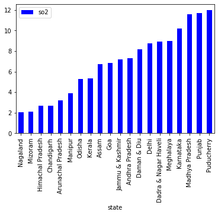

```python
data[['so2','state']].groupby(["state"]).mean().sort_values(by='so2').head(20).plot.bar(color='b')
plt.show()
```

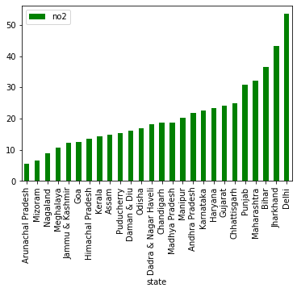

```python
data[['no2','state']].groupby(["state"]).mean().sort_values(by='no2').plot.bar(color='g')
plt.show()
```

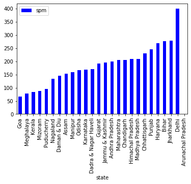

```python
data[['spm','state']].groupby(["state"]).mean().sort_values(by='spm').plot.bar(color='b')
plt.show()
```

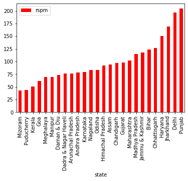

```python
data[['rspm','state']].groupby(["state"]).mean().sort_values(by='rspm').plot.bar(color='r')
plt.show()
```

# NULL VALUES COUNT

```python
data.isna().sum() #print the sum of null values for each columns
```

```
stn_code                       104890
sampling_date                       0
state                               0
location                            0
agency                         108138
type                             3945
so2                             28418
no2                             12591
rspm                            30141
spm                            169222
location_monitoring_station     19644
pm2_5                          298954
date                                5
dtype: int64
```

# DROP UNNECESSARY COLUMN

```python
data.drop(['stn_code','agency','sampling_date','location_monitoring_station'],axis=1,inplace=True)
```

```python
data.head(10)
```

|  | state | location | type | so2 | no2 | rspm | spm | pm2_5 | date |
| --- | --- | --- | --- | --- | --- | --- | --- | --- | --- |
| 0 | Andhra Pradesh | Hyderabad | Residential, Rural and other Areas | 4.8 | 17.4 | NaN | NaN | NaN | 1990-02-01 |
| 1 | Andhra Pradesh | Hyderabad | Industrial Area | 3.1 | 7.0 | NaN | NaN | NaN | 1990-02-01 |
| 2 | Andhra Pradesh | Hyderabad | Residential, Rural and other Areas | 6.2 | 28.5 | NaN | NaN | NaN | 1990-02-01 |
| 3 | Andhra Pradesh | Hyderabad | Residential, Rural and other Areas | 6.3 | 14.7 | NaN | NaN | NaN | 1990-03-01 |
| 4 | Andhra Pradesh | Hyderabad | Industrial Area | 4.7 | 7.5 | NaN | NaN | NaN | 1990-03-01 |
| 5 | Andhra Pradesh | Hyderabad | Residential, Rural and other Areas | 6.4 | 25.7 | NaN | NaN | NaN | 1990-03-01 |
| 6 | Andhra Pradesh | Hyderabad | Residential, Rural and other Areas | 5.4 | 17.1 | NaN | NaN | NaN | 1990-04-01 |
| 7 | Andhra Pradesh | Hyderabad | Industrial Area | 4.7 | 8.7 | NaN | NaN | NaN | 1990-04-01 |
| 8 | Andhra Pradesh | Hyderabad | Residential, Rural and other Areas | 4.2 | 23.0 | NaN | NaN | NaN | 1990-04-01 |
| 9 | Andhra Pradesh | Hyderabad | Industrial Area | 4.0 | 8.9 | NaN | NaN | NaN | 1990-05-01 |

# CALCULATE TOTAL MISSING VALUES AND THEIR PERCENTAGE

```python
total = data.isnull().sum().sort_values(ascending=False)
```

```python
total.head()
```

```
pm2_5    298954
spm      169222
rspm      30141
so2       28418
no2       12591
dtype: int64
```

```python
percent = (data.isnull().sum()/data.isnull().count()*100).sort_values(ascending=False)  #count(returns Non-NAN value)
```

```python
missing_data = pd.concat([total, percent], axis=1, keys=['Total', 'Percent'])
```

```python
missing_data.head()
```

|  | Total | Percent |
| --- | --- | --- |
| pm2_5 | 298954 | 97.436282 |
| spm | 169222 | 55.153510 |
| rspm | 30141 | 9.823675 |
| so2 | 28418 | 9.262108 |
| no2 | 12591 | 4.103709 |

# PERCENT OF MISSING VALUE (BAR PLOT)

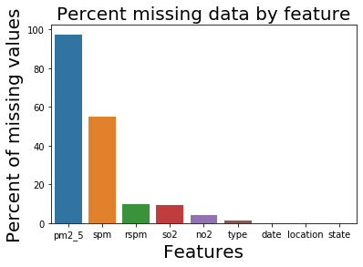

```python
sns.barplot(x=missing_data.index, y=missing_data['Percent'])
plt.xlabel('Features', fontsize=20)
plt.ylabel('Percent of missing values', fontsize=20)
plt.title('Percent missing data by feature', fontsize=20)
```

# MEAN DISTRIBUTION BY STATE

```python
data.groupby('state')[['spm','pm2_5','rspm','so2','no2']].mean()
```

| state | spm | pm2_5 | rspm | so2 | no2 |
| --- | --- | --- | --- | --- | --- |
| Andhra Pradesh | 200.260378 | NaN | 78.182824 | 7.284845 | 21.704451 |
| Arunachal Pradesh | NaN | NaN | 76.629213 | 3.179104 | 5.469697 |
| Assam | 153.355386 | NaN | 93.724912 | 6.723263 | 14.793691 |
| Bihar | 276.917416 | NaN | 123.705176 | 19.381476 | 36.575525 |
| Chandigarh | 206.056150 | NaN | 96.587079 | 2.676986 | 18.619404 |
| Chhattisgarh | 231.290969 | NaN | 126.472399 | 12.846609 | 24.815961 |
| Dadra & Nagar Haveli | 170.545024 | 30.511628 | 76.536530 | 8.939587 | 18.293959 |
| Daman & Diu | 145.681416 | 27.886364 | 73.749431 | 8.192958 | 16.168926 |
| Delhi | 399.402088 | 95.113208 | 196.639771 | 8.737273 | 53.489147 |
| Goa | 67.254193 | 18.855612 | 61.212766 | 6.827913 | 12.506337 |
| Gujarat | 191.567930 | 30.729696 | 98.244510 | 16.656343 | 24.065631 |
| Haryana | 268.264804 | NaN | 149.860537 | 14.064957 | 23.428311 |
| Himachal Pradesh | 208.575630 | NaN | 91.870202 | 2.667013 | 13.658688 |
| Jammu & Kashmir | 196.221053 | NaN | 117.449483 | 7.180521 | 12.213181 |
| Jharkhand | 277.940746 | NaN | 168.517763 | 23.485794 | 43.366341 |
| Karnataka | 168.001743 | NaN | 79.371801 | 10.223099 | 22.702837 |
| Kerala | 84.419791 | NaN | 50.636064 | 5.322350 | 14.421889 |
| Madhya Pradesh | 210.067545 | 65.064565 | 114.717967 | 11.587410 | 18.639596 |
| Maharashtra | 205.255823 | NaN | 101.479608 | 17.366863 | 32.115370 |
| Manipur | 158.657895 | NaN | 69.815789 | 3.900000 | 20.173684 |
| Meghalaya | 78.002445 | NaN | 68.988442 | 8.955908 | 10.659706 |
| Mizoram | 87.833333 | NaN | 42.716466 | 2.085009 | 6.682171 |
| Nagaland | 133.311449 | NaN | 83.357027 | 2.059736 | 8.947265 |
| Odisha | 167.609844 | 42.204089 | 83.619824 | 5.275874 | 16.899568 |
| Puducherry | 95.598188 | NaN | 43.418217 | 11.970639 | 15.279496 |
| Punjab | 244.955519 | NaN | 204.160109 | 11.687963 | 30.947417 |

# CHECKING DATA DISTRIBUTION

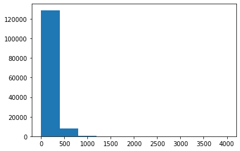

```python
plt.hist(data.spm,range=(0.0,4000)) #spm
```

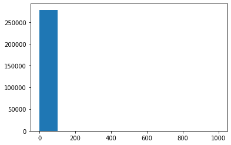

```python
plt.hist(data.so2,range=(0,1000)) #so2
```

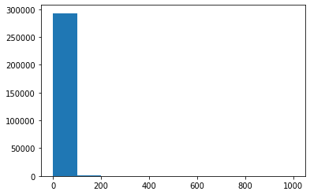

```python
plt.hist(data.no2,range=(0,1000)) #no2
```

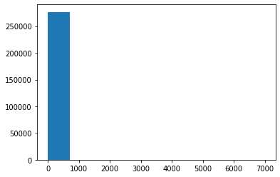

```python
plt.hist(data.rspm,range=(0,7000)) #rspm
```

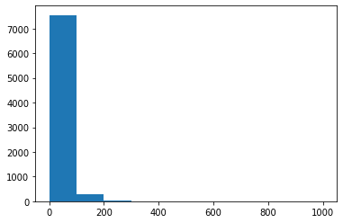

```python
plt.hist(data.pm2_5,range=(0,1000)) #pm2_5
```

# FILL MISSING VALUES BY MEAN (GROUP BY STATE)

```python
grp_state = data.groupby('state')
```

```python
def impute_mean_by_state(series):
    return series.fillna(series.mean())
```

```python
data['rspm']=grp_state['rspm'].transform(impute_mean_by_state)  #fill value with mean value group by state
data['so2']=grp_state['so2'].transform(impute_mean_by_state)
data['no2']=grp_state['no2'].transform(impute_mean_by_state)
data['spm']=grp_state['spm'].transform(impute_mean_by_state)
data['pm2_5']=grp_state['pm2_5'].transform(impute_mean_by_state)
```

```python
data.describe()
```

|  | so2 | no2 | rspm | spm | pm2_5 |
| --- | --- | --- | --- | --- | --- |
| count | 306820.000000 | 306820.000000 | 306820.000000 | 306730.000000 | 76651.000000 |
| mean | 10.379822 | 22.878942 | 99.258878 | 188.948029 | 48.728894 |
| std | 10.232177 | 15.695860 | 64.983383 | 96.825424 | 23.499111 |
| min | 0.000000 | 0.000000 | 0.000000 | 0.000000 | 3.000000 |
| 25% | 4.000000 | 12.800000 | 55.000000 | 133.311449 | 30.729696 |
| 50% | 7.500000 | 19.000000 | 86.000000 | 200.260378 | 42.204089 |
| 75% | 13.420417 | 29.700000 | 123.000000 | 210.067545 | 65.064565 |
| max | 597.000000 | 696.000000 | 1082.000000 | 2213.000000 | 504.000000 |

```python
data.isna().sum() #some null value remains since some state have one value(i.e NaN only) and no mean to replace them
```

```
state            0
location         0
type          3945
so2              0
no2              0
rspm             0
spm             90
pm2_5       230169
date             5
dtype: int64
```

# Data Distribution after Replacing Null value with mean

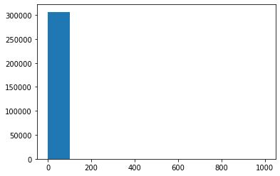

```python
plt.hist(data.so2,range=(0,1000))
```

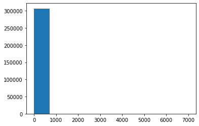

```python
plt.hist(data.rspm,range=(0,7000))
```

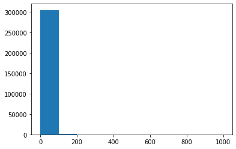

```python
plt.hist(data.no2,range=(0.0,1000))
```

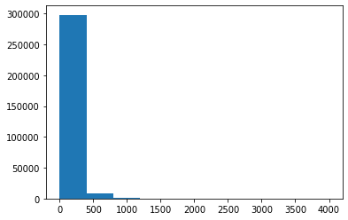

```python
plt.hist(data.spm,range=(0.0,4000)) #spm
```

```python
data.tail(10)
```

|  | state | location | type | so2 | no2 | rspm | spm | pm2_5 | date |
| --- | --- | --- | --- | --- | --- | --- | --- | --- | --- |
| 306810 | Punjab | Khanna | Industrial Area | 12.700000 | 33.000000 | 314.000000 | 244.955519 | NaN | 2011-04-28 |
| 306811 | Punjab | Khanna | Industrial Area | 11.500000 | 30.200000 | 259.000000 | 244.955519 | NaN | 2011-04-30 |
| 306812 | Punjab | Khanna | Industrial Area | 13.300000 | 33.000000 | 269.000000 | 244.955519 | NaN | 2011-03-05 |
| 306813 | Punjab | Khanna | Industrial Area | 13.300000 | 30.300000 | 265.000000 | 244.955519 | NaN | 2011-05-05 |
| 306814 | Punjab | Khanna | Industrial Area | 12.000000 | 31.000000 | 244.000000 | 244.955519 | NaN | 2011-07-05 |
| 306815 | Punjab | Khanna | Industrial Area | 10.500000 | 31.500000 | 277.000000 | 244.955519 | NaN | 2011-10-05 |
| 306816 | Punjab | Khanna | Industrial Area | 11.300000 | 29.800000 | 245.000000 | 244.955519 | NaN | 2011-12-05 |
| 306817 | Punjab | Khanna | Industrial Area | 11.500000 | 31.000000 | 272.000000 | 244.955519 | NaN | 2011-05-14 |
| 306818 | Punjab | Khanna | Industrial Area | 11.500000 | 31.500000 | 215.000000 | 244.955519 | NaN | 2011-05-17 |
| 306819 | Punjab | Kh | NaN | 11.687963 | 30.947417 | 204.160109 | 244.955519 | NaN | NaN |

[figure not shown]

**NO2 :** Nitrogen dioxide is a nasty-smelling gas. Some nitrogen dioxide is formed naturally in the atmosphere by lightning and some is produced by plants, soil and water. However, only about 1% of the total amount of nitrogen dioxide found in our cities' air is formed this way.

Nitrogen dioxide is an important air pollutant because it contributes to the formation of photochemical smog, which can have significant impacts on human health.

The major source of nitrogen dioxide in is the burning of fossil fuels: coal, oil and gas.

The main effect of breathing in raised levels of nitrogen dioxide is the increased likelihood of respiratory problems. Nitrogen dioxide inflames the lining of the lungs, and it can reduce immunity to lung infections. This can cause problems such as wheezing, coughing, colds, flu and bronchitis.

Increased levels of nitrogen dioxide can have significant impacts on people with asthma because it can cause more frequent and more intense attacks. Children with asthma and older people with heart disease are most at risk.

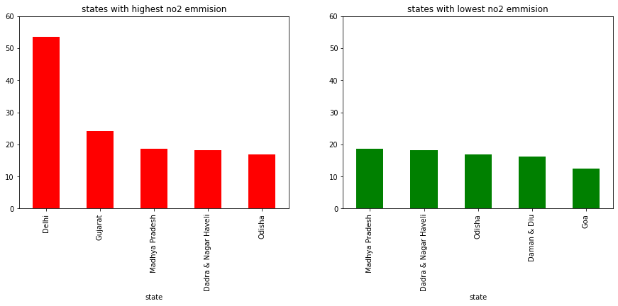

```python
fig, axarr = plt.subplots(1, 2, squeeze=False, figsize=(15,5))

data[['state','no2']].groupby('state').mean().sort_values(by='no2',ascending=False).head().plot(kind='bar',
                                                                                              ax=axarr[0][0],
                                                                                              color='red',
                                                                                              title='states with highest no2 emmision',
                                                                                              yticks=range(0,61,10),
                                                                                              legend=False)

data[['state','no2']].groupby('state').mean().sort_values(by='no2',ascending=False).tail().plot(kind='bar',
                                                                                              ax=axarr[0][1],
                                                                                              color='green',
                                                                                              title='states with lowest no2 emmision',
                                                                                              yticks=range(0,61,10),
                                                                                              legend=False)
plt.show()
```

# SO2 : Sulfur dioxide is a gas. It is invisible and has a nasty, sharp smell. It reacts easily with other substances to form harmful compounds, such as sulfuric acid, sulfurous acid and sulfate particles.

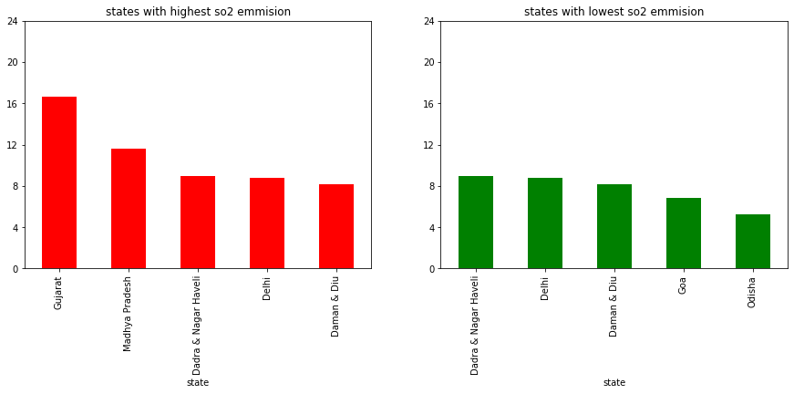

```python
fig, axarr = plt.subplots(1, 2, squeeze=False, figsize=(15,5))

data[['state','so2']].groupby('state').mean().sort_values(by='so2',ascending=False).head().plot(kind='bar',
                                                                                              ax=axarr[0][0],
                                                                                              color='red',
                                                                                              title='states with highest so2 emmision',
                                                                                              yticks=range(0,25,4),
                                                                                              legend=False)

data[['state','so2']].groupby('state').mean().sort_values(by='so2',ascending=False).tail().plot(kind='bar',
                                                                                              ax=axarr[0][1],
                                                                                              color='green',
                                                                                              title='states with lowest so2 emmision',
                                                                                              yticks=range(0,25,4),
                                                                                              legend=False)
plt.show()
```

RSPM(Respirable Suspended Particulate Matter) : RSPM is that fraction of TSPM which is readily inhaled by humans through their respiratory system and in general, considered as particulate matter with their diameter (aerodynamic) less than 2.5 micrometers. Larger particles would be filtered in the nasal duct.

(TSPM: Stands for Total Suspended Particulate Matter and would essentially be the concentration one would get when a high-volume bulk sampling is done on a filter substrate.)

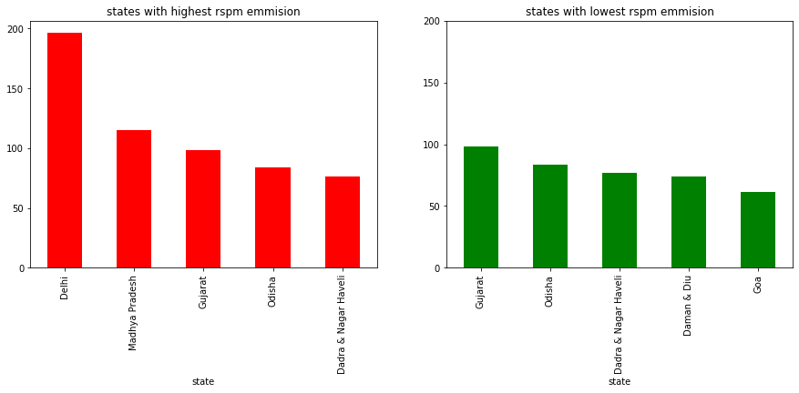

```python
fig, axarr = plt.subplots(1, 2, squeeze=False, figsize=(15,5))

data[['state','rspm']].groupby('state').mean().sort_values(by='rspm',ascending=False).head().plot(kind='bar',
                                                                                              ax=axarr[0][0],
                                                                                              color='red',
                                                                                              title='states with highest rspm emmision',
                                                                                              yticks=range(0,250,50),
                                                                                              legend=False)

data[['state','rspm']].groupby('state').mean().sort_values(by='rspm',ascending=False).tail().plot(kind='bar',
                                                                                              ax=axarr[0][1],
                                                                                              color='green',
                                                                                              title='states with lowest rspm emmision',
                                                                                              yticks=range(0,250,50),
                                                                                              legend=False)
plt.show()
```

PM 2.5 : Fine particulate matter (PM2.5) is an air pollutant that is a concern for people's health when levels in air are high. PM2.5 are tiny particles in the air that reduce visibility and cause the air to appear hazy when levels are elevated. Outdoor PM2.5 levels are most likely to be elevated on days with little or no wind or air mixing

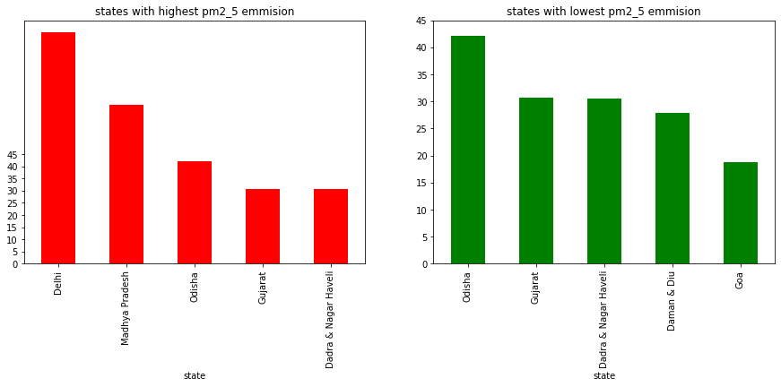

```python
fig, axarr = plt.subplots(1, 2, squeeze=False, figsize=(15,5))

data[['state','pm2_5']].groupby('state').mean().sort_values(by='pm2_5',ascending=False).head().plot(kind='bar',
                                                                                              ax=axarr[0][0],
                                                                                              color='red',
                                                                                              title='states with highest pm2_5 emmision',
                                                                                              yticks=range(0,50,5),
                                                                                              legend=False)

data[['state','pm2_5']].groupby('state').mean().sort_values(by='pm2_5',ascending=False).tail().plot(kind='bar',
                                                                                              ax=axarr[0][1],
                                                                                              color='green',
                                                                                              title='states with lowest pm2_5 emmision',
                                                                                              yticks=range(0,50,5),
                                                                                              legend=False)
plt.show()
```

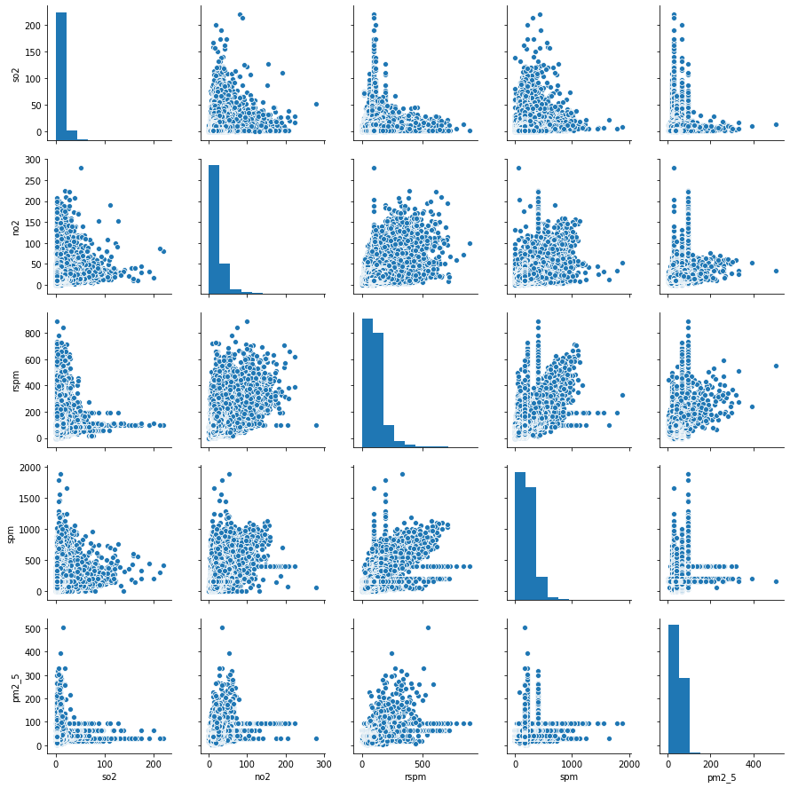

```python
sns.pairplot(data[['so2','no2','rspm','spm','pm2_5']])
```

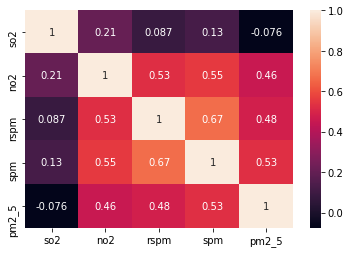

```python
sns.heatmap(data.loc[:, ['state','so2', 'no2', 'rspm', 'spm', 'pm2_5']].corr(), annot=True)
```

**from this we can infere that :**

- **SO2 conc.**

[output not shown]

- **NO2 conc.**

[output not shown]

- **SPM conc.**

[output not shown]

- **pm2.5 conc.**

[output not shown]

# CALCULATE AIR QUALITY INDEX FOR SO2 BASED ON FORMULA

The air quality index is a piecewise linear function of the pollutant concentration. At the boundary between AQI categories, there is a discontinuous jump of one AQI unit. To convert from concentration to AQI this equation is used \begin{equation*} I = I_{low} + \frac{I_{high}-I_{low}}{C_{high}-C_{low}}{(C-C_{low})} \end{equation*}

**What is sulfur dioxide?**

Sulfur dioxide is a gas. It is invisible and has a nasty, sharp smell. It reacts easily with other substances to form harmful compounds, such as sulfuric acid, sulfurous acid and sulfate particles.

About 99% of the sulfur dioxide in air comes from human sources. The main source of sulfur dioxide in the air is industrial activity that processes materials that contain sulfur, eg the generation of electricity from coal, oil or gas that contains sulfur. Some mineral ores also contain sulfur, and sulfur dioxide is released when they are processed. In addition, industrial activities that burn fossil fuels containing sulfur can be important sources of sulfur dioxide.

Sulfur dioxide is also present in motor vehicle emissions, as the result of fuel combustion. In the past, motor vehicle exhaust was an important, but not the main, source of sulfur dioxide in air. However, this is no longer the case.

```python
def cal_SOi(so2):
    si=0
    if (so2<=40):
     si= so2*(50/40)
    elif (so2>40 and so2<=80):
     si= 50+(so2-40)*(50/40)
    elif (so2>80 and so2<=380):
     si= 100+(so2-80)*(100/300)
    elif (so2>380 and so2<=800):
     si= 200+(so2-380)*(100/420)
    elif (so2>800 and so2<=1600):
     si= 300+(so2-800)*(100/800)
    elif (so2>1600):
     si= 400+(so2-1600)*(100/800)
    return si
data['SOi']=data['so2'].apply(cal_SOi)
df= data[['so2','SOi']]
df.head()
```

|  | so2 | SOi |
| --- | --- | --- |
| 0 | 4.8 | 6.000 |
| 1 | 3.1 | 3.875 |
| 2 | 6.2 | 7.750 |
| 3 | 6.3 | 7.875 |
| 4 | 4.7 | 5.875 |

# CALCULATE AIR QUALITY INDEX FOR NO2 BASED ON FORMULA

```python
def cal_Noi(no2):
    ni=0
    if(no2<=40):
     ni= no2*50/40
    elif(no2>40 and no2<=80):
     ni= 50+(no2-40)*(50/40)
    elif(no2>80 and no2<=180):
     ni= 100+(no2-80)*(100/100)
    elif(no2>180 and no2<=280):
     ni= 200+(no2-180)*(100/100)
    elif(no2>280 and no2<=400):
     ni= 300+(no2-280)*(100/120)
    else:
     ni= 400+(no2-400)*(100/120)
    return ni
data['Noi']=data['no2'].apply(cal_Noi)
df= data[['no2','Noi']]
df.head()
```

|  | no2 | Noi |
| --- | --- | --- |
| 0 | 17.4 | 21.750 |
| 1 | 7.0 | 8.750 |
| 2 | 28.5 | 35.625 |
| 3 | 14.7 | 18.375 |
| 4 | 7.5 | 9.375 |

# CALCULATE AIR QUALITY INDEX FOR RSPM BASED ON FORMULA

```python
def cal_RSPMi(rspm):
    rpi=0
    if(rspm<=100):
     rpi = rspm
    elif(rspm>=101 and rspm<=150):
     rpi= 101+(rspm-101)*((200-101)/(150-101))
    elif(rspm>=151 and rspm<=350):
     ni= 201+(rspm-151)*((300-201)/(350-151))
    elif(rspm>=351 and rspm<=420):
     ni= 301+(rspm-351)*((400-301)/(420-351))
    elif(rspm>420):
     ni= 401+(rspm-420)*((500-401)/(420-351))
    return rpi
data['RSPMi']=data['rspm'].apply(cal_RSPMi)
df= data[['rspm','RSPMi']]
df.head()
```

|  | rspm | RSPMi |
| --- | --- | --- |
| 0 | 78.182824 | 78.182824 |
| 1 | 78.182824 | 78.182824 |
| 2 | 78.182824 | 78.182824 |
| 3 | 78.182824 | 78.182824 |
| 4 | 78.182824 | 78.182824 |

```python
df.tail()
```

|  | rspm | RSPMi |
| --- | --- | --- |
| 306815 | 277.000000 | 0.0 |
| 306816 | 245.000000 | 0.0 |
| 306817 | 272.000000 | 0.0 |
| 306818 | 215.000000 | 0.0 |
| 306819 | 204.160109 | 0.0 |

# CALCULATE AIR QUALITY INDEX FOR SPM BASED ON FORMULA

```python
def cal_SPMi(spm):
    spi=0
    if(spm<=50):
     spi=spm*50/50
    elif(spm>50 and spm<=100):
     spi=50+(spm-50)*(50/50)
    elif(spm>100 and spm<=250):
     spi= 100+(spm-100)*(100/150)
    elif(spm>250 and spm<=350):
     spi=200+(spm-250)*(100/100)
    elif(spm>350 and spm<=430):
     spi=300+(spm-350)*(100/80)
    else:
     spi=400+(spm-430)*(100/430)
    return spi

data['SPMi']=data['spm'].apply(cal_SPMi)
df= data[['spm','SPMi']]
df.head()
```

|  | spm | SPMi |
| --- | --- | --- |
| 0 | 200.260378 | 166.840252 |
| 1 | 200.260378 | 166.840252 |
| 2 | 200.260378 | 166.840252 |
| 3 | 200.260378 | 166.840252 |
| 4 | 200.260378 | 166.840252 |